# # 1. Imports

```python
import pandas as pd
import numpy as np
import matplotlib.pyplot as plt
import seaborn as sns
import statsmodels.api as sm

from sklearn.model_selection import train_test_split
from sklearn.preprocessing import StandardScaler
from sklearn.linear_model import LinearRegression
from sklearn.ensemble import RandomForestRegressor
from sklearn.metrics import mean_squared_error, r2_score, accuracy_score
from sklearn.tree import DecisionTreeClassifier, DecisionTreeRegressor, plot_tree
```

# # 2. Data Preprocessing

```python
def preprocess_student_data(df, pass_threshold=70):
    """
    Cleans and encodes student data.
    Adds Pass/Fail columns based on exam score.
    """
    df_clean = df.dropna().copy()

    # Map ordinal categories
    mapping = {
        'Family_Income': {'Low':1, 'Medium':2, 'High':3},
        'Parental_Education_Level': {'High School':1, 'College':2, 'Postgraduate':3},
        'Parental_Involvement': {'Low':1, 'Medium':2, 'High':3},
        'Access_to_Resources': {'Low':1, 'Medium':2, 'High':3},
        'Teacher_Quality': {'Low':1, 'Medium':2, 'High':3},
        'Motivation_Level': {'Low':1, 'Medium':2, 'High':3},
        'Distance_from_Home': {'Far':1, 'Moderate':2, 'Near':3},
        'Peer_Influence': {'Negative':1, 'Neutral':2, 'Positive':3}
    }
    for col, map_vals in mapping.items():
        df_clean[col] = df_clean[col].replace(map_vals)

    # One-hot encode binary categories
    binary_cols = ['School_Type', 'Extracurricular_Activities', 'Internet_Access',
                   'Learning_Disabilities', 'Gender']
    df_clean = pd.get_dummies(df_clean, columns=binary_cols, drop_first=True)

    # Add pass/fail columns
    df_clean['Pass_Fail_N'] = (df_clean['Exam_Score'] >= pass_threshold).astype(int)
    df_clean['Pass_Fail'] = df_clean['Exam_Score'].apply(lambda x: 'Pass' if x >= pass_threshold else 'Fail')

    return df_clean

# Load and preprocess data
df = pd.read_csv("StudentPerformanceFactors.csv")
df = preprocess_student_data(df)
df.head()
```

|  | Hours_Studied | Attendance | Parental_Involvement | Access_to_Resources | Sleep_Hours | Previous_Scores | Motivation_Level | Tutoring_Sessions | Family_Income | Teacher_Quality | ... | Parental_Education_Level | Distance_from_Home | Exam_Score | School_Type_Public | Extracurricular_Activities_Yes | Internet_Access_Yes | Learning_Disabilities_Yes | Gender_Male | Pass_Fail_N | Pass_Fail |
| --- | --- | --- | --- | --- | --- | --- | --- | --- | --- | --- | --- | --- | --- | --- | --- | --- | --- | --- | --- | --- | --- |
| 0 | 23 | 84 | 1 | 3 | 7 | 73 | 1 | 0 | 1 | 2 | ... | 1 | 3 | 67 | True | False | True | False | True | 0 | Fail |
| 1 | 19 | 64 | 1 | 2 | 8 | 59 | 1 | 2 | 2 | 2 | ... | 2 | 2 | 61 | True | False | True | False | False | 0 | Fail |
| 2 | 24 | 98 | 2 | 2 | 7 | 91 | 2 | 2 | 2 | 2 | ... | 3 | 3 | 74 | True | True | True | False | True | 1 | Pass |
| 3 | 29 | 89 | 1 | 2 | 8 | 98 | 2 | 1 | 2 | 2 | ... | 1 | 2 | 71 | True | True | True | False | True | 1 | Pass |
| 4 | 19 | 92 | 2 | 2 | 6 | 65 | 2 | 3 | 2 | 3 | ... | 2 | 3 | 70 | True | True | True | False | False | 1 | Pass |

5 rows × 22 columns

# # 3. Exploratory Data Analysis

The features that had the greatest effect on exam performance were those directly under the student's control, such as attendance, hours studied, and previous scores. These features are also continuous variables, which may partly explain their stronger influence on the outcome.

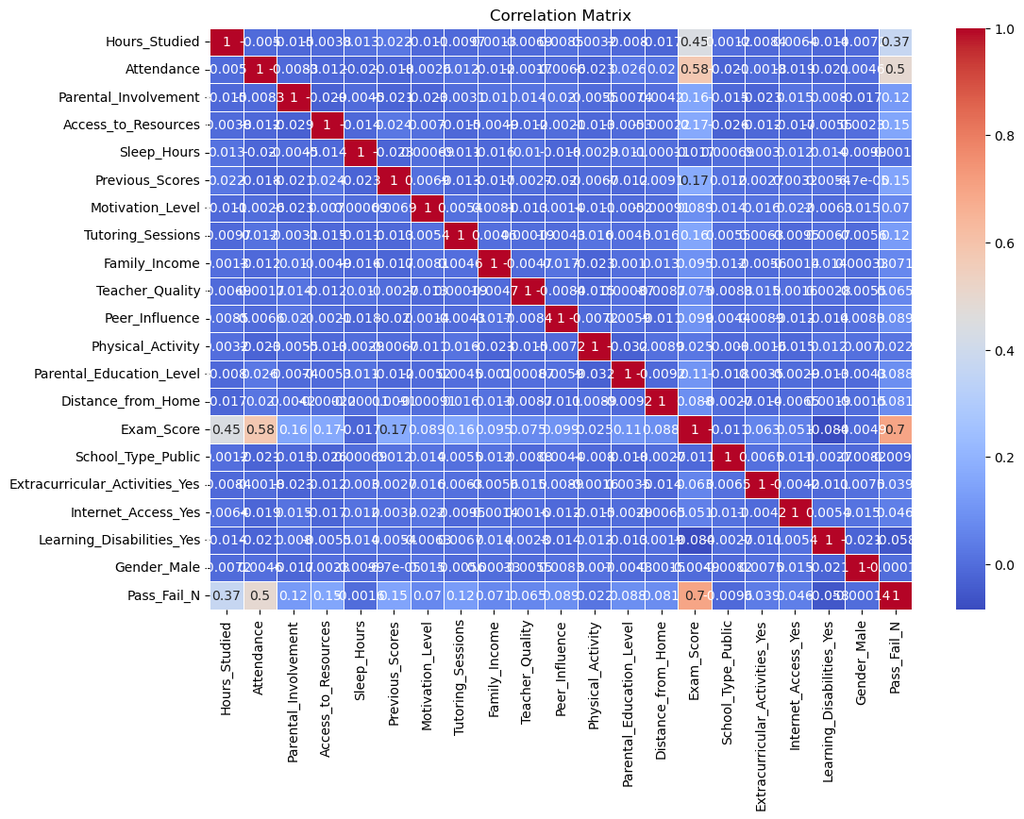

```
Exam_Score                        1.000000
Pass_Fail_N                       0.697625
Attendance                        0.580259
Hours_Studied                     0.445104
Previous_Scores                   0.174283
Access_to_Resources               0.167856
Tutoring_Sessions                 0.156829
Parental_Involvement              0.156014
Parental_Education_Level          0.105253
Peer_Influence                    0.099133
Family_Income                     0.094555
Motivation_Level                  0.088502
Distance_from_Home                0.088083
Teacher_Quality                   0.075107
Extracurricular_Activities_Yes    0.063063
Internet_Access_Yes               0.051124
Physical_Activity                 0.025148
Gender_Male                      -0.004932
School_Type_Public               -0.010868
Sleep_Hours                      -0.017171
Learning_Disabilities_Yes        -0.083911
Name: Exam_Score, dtype: float64
```

```python
def analyze_correlations(df):
    corr_matrix = df.corr(numeric_only=True)
    exam_corr = corr_matrix['Exam_Score'].sort_values(ascending=False)

    plt.figure(figsize=(12,8))
    sns.heatmap(corr_matrix, annot=True, cmap='coolwarm', linewidths=0.5)
    plt.title("Correlation Matrix")
    plt.show()

    return exam_corr

correlations = analyze_correlations(df)
print(correlations)
```

# 4. Regression Models

## Research Question 1: What is the best ML model to predict the final exam score? How can I improve the initial model?

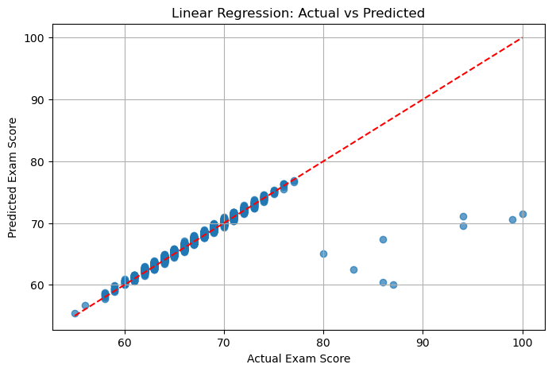

```
Linear Results -> MSE: 4.15, R²: 0.73
```

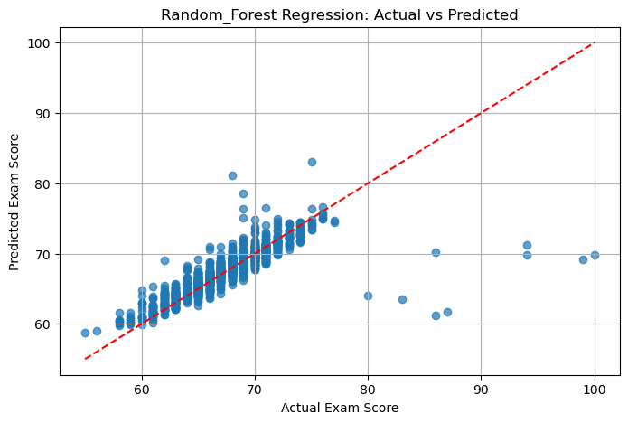

```
Random_Forest Results -> MSE: 5.82, R²: 0.63
```

```python
def run_regression(df, model_type='linear', test_size=0.2, random_state=42):
    X = df.drop(columns=['Exam_Score', 'Pass_Fail', 'Pass_Fail_N'])
    y = df['Exam_Score']

    X_train, X_test, y_train, y_test = train_test_split(X, y, test_size=test_size, random_state=random_state)
    scaler = StandardScaler()
    X_train_scaled = scaler.fit_transform(X_train)
    X_test_scaled = scaler.transform(X_test)

    if model_type == 'random_forest':
        model = RandomForestRegressor(n_estimators=100, random_state=random_state)
    else:
        model = LinearRegression()

    model.fit(X_train_scaled, y_train)
    y_pred = model.predict(X_test_scaled)

    mse = mean_squared_error(y_test, y_pred)
    r2 = r2_score(y_test, y_pred)

    plt.figure(figsize=(8,5))
    plt.scatter(y_test, y_pred, alpha=0.7)
    plt.plot([y_test.min(), y_test.max()], [y_test.min(), y_test.max()], 'r--')
    plt.xlabel("Actual Exam Score")
    plt.ylabel("Predicted Exam Score")
    plt.title(f"{model_type.title()} Regression: Actual vs Predicted")
    plt.grid(True)
    plt.show()

    print(f"{model_type.title()} Results -> MSE: {mse:.2f}, R²: {r2:.2f}")
    return model, mse, r2

linear_model, _, _ = run_regression(df, 'linear')
rf_model, _, _ = run_regression(df, 'random_forest')
```

# Roadblock & Learning: Decision Trees

Initially, I attempted to use a Decision Tree Classifier to predict exact exam scores. This was the wrong approach because classifiers are meant for categorical outcomes, not continuous values. As a result, the initial accuracy was very low (~21%), even after attempting to drop weak features.

This made me realize that Decision Trees are better suited for classification tasks. I created a **Pass/Fail** column using a threshold of 70 and retrained the classifier, which significantly improved predictive performance.

```python
# Example of the initial (incorrect) approach
from sklearn.tree import DecisionTreeClassifier
from sklearn.metrics import accuracy_score
from sklearn.model_selection import train_test_split
from sklearn.linear_model import LinearRegression

X = df.drop(columns=['Exam_Score', 'Pass_Fail', 'Pass_Fail_N'])
y = df['Exam_Score']

X_train, X_test, y_train, y_test = train_test_split(X, y, test_size=0.2, random_state=42)

# Linear Regression (correct for continuous)
model = LinearRegression()
model.fit(X_train, y_train)
y_pred = model.predict(X_test)

# Incorrect: Decision Tree Classifier on continuous exam scores
clf = DecisionTreeClassifier()
clf.fit(X_train, y_train)
y_pred_cls = clf.predict(X_test)
print("Initial Accuracy:", accuracy_score(y_test, y_pred_cls))
```

```
Initial Accuracy: 0.2029780564263323
```

# # 5. Pass/Fail Classification

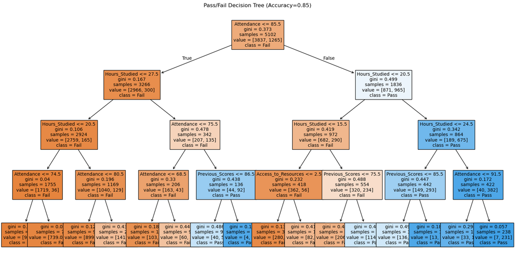

```
Classification Accuracy: 0.85
```

```python
def classify_pass_fail(df, features=None, test_size=0.2, max_depth=4):
    if features is None:
        features = ['Hours_Studied', 'Attendance', 'Previous_Scores', 'Access_to_Resources']

    X = df[features]
    y = df['Pass_Fail']

    X_train, X_test, y_train, y_test = train_test_split(X, y, test_size=test_size, random_state=42)
    clf = DecisionTreeClassifier(max_depth=max_depth, random_state=42)
    clf.fit(X_train, y_train)

    y_pred = clf.predict(X_test)
    acc = accuracy_score(y_test, y_pred)

    plt.figure(figsize=(20,10))
    plot_tree(clf, feature_names=features, class_names=['Fail','Pass'], filled=True, fontsize=10)
    plt.title(f"Pass/Fail Decision Tree (Accuracy={acc:.2f})")
    plt.show()

    print(f"Classification Accuracy: {acc:.2f}")
    return clf, acc

clf_model, clf_acc = classify_pass_fail(df)
```

The MSE is low because most students score between 60 and 75, making predictions easier, but R² is only around 50% due to many outliers.

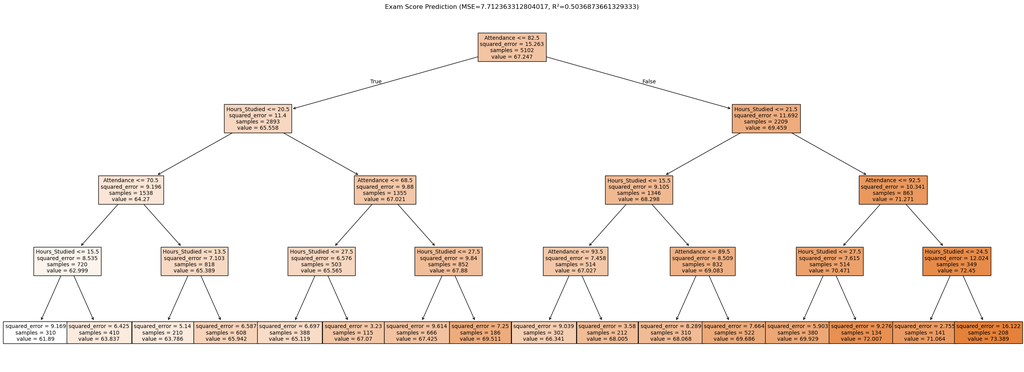

```
Regression MSE: 7.712363312804017, R²: 0.5036873661329333
```

```python
def analyze_exam_scores(df, test_size=0.2):
    """
    Predicts exam scores using decision tree
    Returns: model, prediction error (MSE), and accuracy score (R²)
    """
    # Remove unnessecary columns
    X = df.drop(columns=['Exam_Score', 'Pass_Fail', 'Pass_Fail_N'])
    y = df['Exam_Score']  # what we want to predict

    # Split Data
    # Divide into training (80%) and testing (20%) sets
    X_train, X_test, y_train, y_test = train_test_split(
        X, y, test_size=test_size, random_state=42)

    #Train Model
    model = DecisionTreeRegressor(
        max_depth=4,          # Don't make tree too complex
        min_samples_leaf=5,  # Need at least 5 samples per leaf
        random_state=42    # Consistency
    )
    model.fit(X_train, y_train)  # Teach the model using training data

    # Evaluate
    y_pred = model.predict(X_test)  # Make predictions on test data
    mse = mean_squared_error(y_test, y_pred)  # How far off predictions are (lower = better)
    r2 = r2_score(y_test, y_pred)   # % of score variation explained (0-1, higher=better)

    # Visualize Tree
    plt.figure(figsize=(34,12))#trialed and errored size to fit all squares
    plot_tree(model, feature_names=X.columns, filled=True,
             max_depth=5, fontsize=10)
    plt.title(f"Exam Score Prediction (MSE={mse}, R²={r2})")
    plt.show()

    return model, mse, r2

# Run the analysis
reg_model, reg_mse, reg_r2 = analyze_exam_scores(df)
print(f"Regression MSE: {reg_mse}, R²: {reg_r2}")
```

## Research Question 1 Analysis

### Linear and Random Forest Regression

- **Linear Regression** outperforms Random Forest:
  - MSE: 4.15 vs 5.82
  - R²: 0.73 vs 0.63
- Both models **underestimate top-performing students** (scores >80–85) due to majority of students scoring in 60–75%.
- Models are reliable for predicting lower and mid-range scores but fail to capture features that make top scorers.

**Implication:** Regression models are useful for general performance trends but not for identifying highest achievers.

## Research Question 2: How much of an effect do people have in student's lives in their exam scores?

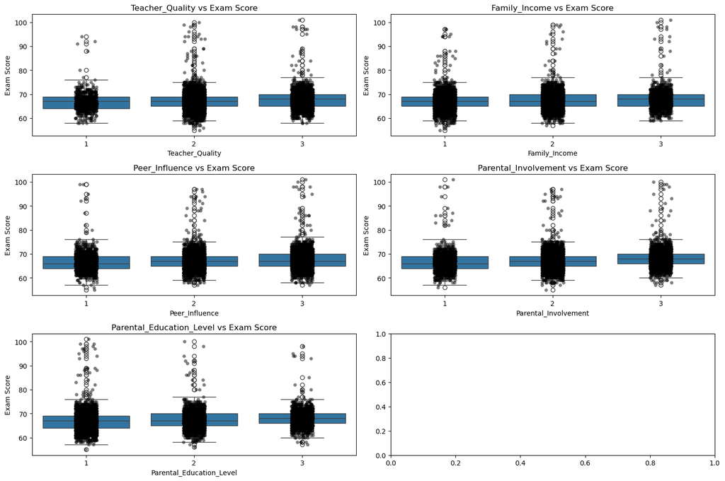

```python
import statsmodels.api as sm # https://www.statology.org/statsmodels-linear-regression-p-value/
import pandas as pd

def plot_feature_score_relationships(df):
    """Visualizes relationships between social factors and exam scores using boxplots with data points."""

    # List of features we want to analyze against exam scores
    features = ['Teacher_Quality', 'Family_Income', 'Peer_Influence',
               'Parental_Involvement', 'Parental_Education_Level']

    # Create the main figure container
    plt.figure(figsize=(18, 10))

    # Create a 3x2 grid of subplots (for 5 features + 1 empty)
    fig, axes = plt.subplots(3, 2, figsize=(15, 10))

    # Convert the 2D array of subplots into a flat 1D array for easy looping
    axes = axes.flatten()

    # Loop through each feature to create its visualization
    for i, feature in enumerate(features):
        # Create boxplot showing score distribution for each feature category
        sns.boxplot(x=feature, y='Exam_Score', data=df, ax=axes[i])

        # Overlay individual data points on the boxplot for better density visualization
        sns.stripplot(x=feature, y='Exam_Score', data=df, ax=axes[i],
                     color='black', alpha=0.5, jitter=True)

        # Add title showing which feature is being visualized
        axes[i].set_title(f'{feature} vs Exam Score')

        # Label the x-axis
        axes[i].set_xlabel(feature)

        # Label the y-axis
        axes[i].set_ylabel('Exam Score')


    # prevent overlap, neater
    plt.tight_layout()

    plt.show()
plot_feature_score_relationships(df)
```

```python
def analyze_exam_score_impact(df, features=None, target='Exam_Score'):
    """
    Performs OLS regression to see how much each feature increases exam scores.
    Args:
        df: DataFrame
        features: List of social features to analyze (default: Teacher_Quality', 'Family_Income', 'Peer_Influence', 'Parental_Involvement', 'Parental_Education_Level)
        target: Target variable ('Exam_Score')

    Returns:
        coefficients and p-values of features
    """
    # Set default features
    if features is None:
        features = ['Teacher_Quality', 'Family_Income', 'Peer_Influence', 'Parental_Involvement', 'Parental_Education_Level']

    # Prepare data
    X = df[features]
    y = df[target]

    # Add intercept term
    X = sm.add_constant(X)

    # Fit OLS model
    model = sm.OLS(y, X).fit()

    # Create results summary
    results = pd.DataFrame({
        'Feature': ['Intercept'] + features,
        'Coefficient': model.params,
        'P-value': model.pvalues,})


    print("OLS Regression Results")
    print(results[['Feature', 'Coefficient', 'P-value']])

    return model, results

analyze_exam_score_impact(df)
```

```
OLS Regression Results
                                           Feature  Coefficient       P-value
const                                    Intercept    61.560137  0.000000e+00
Teacher_Quality                    Teacher_Quality     0.482052  1.202499e-09
Family_Income                        Family_Income     0.482396  5.470385e-14
Peer_Influence                      Peer_Influence     0.488966  9.052567e-15
Parental_Involvement          Parental_Involvement     0.860713  8.355593e-36
Parental_Education_Level  Parental_Education_Level     0.529844  4.460957e-18
```

```
(<statsmodels.regression.linear_model.RegressionResultsWrapper at 0x152adfd90>,
                                            Feature  Coefficient       P-value
 const                                    Intercept    61.560137  0.000000e+00
 Teacher_Quality                    Teacher_Quality     0.482052  1.202499e-09
 Family_Income                        Family_Income     0.482396  5.470385e-14
 Peer_Influence                      Peer_Influence     0.488966  9.052567e-15
 Parental_Involvement          Parental_Involvement     0.860713  8.355593e-36
 Parental_Education_Level  Parental_Education_Level     0.529844  4.460957e-18)
```

```
Accuracy: 0.75
```

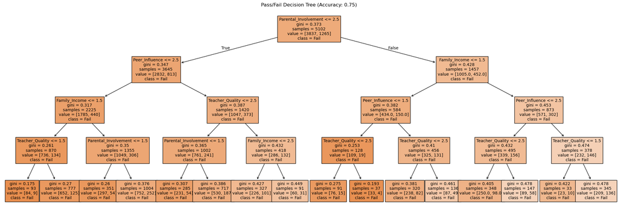

```python
def predict_pass_fail_with_relationships(df, features=None, target='Pass_Fail',test_size=0.2, max_depth=4, min_samples_leaf=5, random_state=42):
    """
    Predicts pass/fail outcomes using only relationship-based features with a decision tree.

    Args:
        df: DataFrame containing student data
        features: List of relationship features to use
        target: Target column name ('Pass_Fail')
        test_size: Proportion for test split ( 0.2)
        max_depth: Maximum tree depth (default: 4)#fits figure easily
        min_samples_leaf: Minimum samples per leaf (default: 5)
        random_state: Random seed (default: 42)

    Returns:
        clf: Trained classifier
        accuracy: Test accuracy score
    """
    # Set default relationship features
    if features is None:
        features = ['Teacher_Quality', 'Family_Income',
                   'Peer_Influence', 'Parental_Involvement']

    # Prepare data - using only the selected relationship features
    X = df[features]
    y = df[target]  #  we want to predict pass/fail

    # Split data into training (80%) and testing (20%) sets
    X_train, X_test, y_train, y_test = train_test_split(
        X, y, test_size=test_size, random_state=random_state)

    # Initialize Decision Tree Classifier with optimized parameters
    # max_depth=4 was chosen because depth 3 and 5 had similar accuracy,
    # but 4 gave the best balance
    clf = DecisionTreeClassifier(
        max_depth=max_depth,
        min_samples_leaf=min_samples_leaf,
        random_state=random_state  # Ensures consistent results across runs
    )

    # Train the model
    clf.fit(X_train, y_train)

    # Make predictions on our test section
    y_pred = clf.predict(X_test)

    # Calculate accuracy -
    accuracy = accuracy_score(y_test, y_pred)
    print(f"Accuracy: {accuracy:.2f}")  # Formatted to 2 decimal places

    # Visualize the decision tree
    plt.figure(figsize=(27, 9))  # Large figure used trial and error to fit everything
    plot_tree(clf,
              feature_names=features,  # Use feature names
              class_names=['Fail', 'Pass'],  # Proper labels for our outcomes
              filled=True,  # Color coding by class
              fontsize=10)  # Readable font size
    plt.title(f"Pass/Fail Decision Tree (Accuracy: {accuracy:.2f})")
    plt.show()

    return clf, accuracy

#call funxxtion
model, acc = predict_pass_fail_with_relationships(df)
```

## Research Question 2 Analysis

### Boxplot Analysis

- **Teacher Quality vs Exam Score**: Median scores slightly increase from level 1 to 3, with similar spread and outliers. Teacher quality has minimal effect on exam scores.
- **Family Income vs Exam Score**: Slight increase in median scores and high-score outliers as income rises, suggesting minimal impact on exam outcomes.
- **Peer Influence vs Exam Score**: Median scores remain nearly identical across levels; spread and distribution are similar. Peer influence has little effect.
- **Parental Involvement vs Exam Score**: Slight increase in median and spread from level 1 to 3, with more high-score outliers at level 3. Greater parental involvement may positively affect exam outcomes.

### Regression Analysis

- All factors are statistically significant (**p < 0.05**) with positive coefficients:
  - Teacher Quality: +0.48 per unit
  - Family Income: +0.48 per unit
  - Peer Influence: +0.49 per unit
  - Parental Involvement: +0.85 per unit
- Parental involvement has the strongest effect on exam scores (almost double other factors).
- Model has low explanatory power (**R² ≈ 0.04**) due to limited feature range (1–3) and low correlation. Small coefficients suggest moderate predictive value.

**Implications:** Schools could host annual workshops to guide parents on supportive, non-overbearing involvement in their children’s education.

# 7. Optimal Feature Values for Exam Score

```python
def find_optimal_values(df, target='Exam_Score'):
    optimal_values = {}
    for col in df.columns:
        if col == target: continue
        if df[col].nunique() < 10:
            best_val = df.groupby(col)[target].mean().idxmax()
            avg_score = df.groupby(col)[target].mean().max()
        else:
            top_5pct = df[col].quantile(0.95)
            avg_score = df[df[col] >= top_5pct][target].mean()
            best_val = f">{top_5pct}"
        optimal_values[col] = (best_val, avg_score)

    for var, (val, score) in optimal_values.items():
        print(f"{var}: {val} (Avg score: {score:.2f})")

    return optimal_values

optimal_values = find_optimal_values(df)
```

```
Hours_Studied: >30.0 (Avg score: 70.91)
Attendance: >98.0 (Avg score: 70.81)
Parental_Involvement: 3 (Avg score: 68.11)
Access_to_Resources: 3 (Avg score: 68.10)
Sleep_Hours: 4 (Avg score: 67.69)
Previous_Scores: >97.0 (Avg score: 68.14)
Motivation_Level: 3 (Avg score: 67.74)
Tutoring_Sessions: 6 (Avg score: 71.67)
Family_Income: 3 (Avg score: 67.84)
Teacher_Quality: 3 (Avg score: 67.68)
Peer_Influence: 3 (Avg score: 67.64)
Physical_Activity: 6 (Avg score: 68.19)
Parental_Education_Level: 3 (Avg score: 67.97)
Distance_from_Home: 3 (Avg score: 67.51)
School_Type_Public: False (Avg score: 67.32)
Extracurricular_Activities_Yes: True (Avg score: 67.45)
Internet_Access_Yes: True (Avg score: 67.31)
Learning_Disabilities_Yes: False (Avg score: 67.36)
Gender_Male: False (Avg score: 67.27)
Pass_Fail_N: 1 (Avg score: 72.01)
Pass_Fail: Pass (Avg score: 72.01)
```

## Research Question 3 Conclusion

- **Key Findings:**
  - **Hours Studied >30** and **Attendance >98%** correlate with higher exam scores (70.9 and 70.8, respectively). Consistency and effort strongly influence performance.
  - **Tutoring Sessions ≥ 6** show the strongest effect (71.7), highlighting the benefit of individualized support.
  - Categorical variables (Teacher Quality, Motivation, etc.) are optimized at level 3, as expected.
- **Surprising Findings:**
  - **Sleep Hours = 4** appears "optimal," contradicting typical health advice. Likely due to last-minute studying or specific student behavior (e.g., college students pulling all-nighters).
  - **Physical Activity Level 6** correlates with better scores. Possibly reflects disciplined students with good time management.
- **Minor Factors:**
  - Internet access, extracurriculars, student disability, and gender show minimal impact.
  - Public schools slightly underperform vs. private schools, explaining some preference for private education.
- **Recommendation:**  
  Students should prioritize **tutoring, attendance, and study hours**—these controllable factors have the most impact on exam performance, rather than factors like parental income or teacher quality.